# Dokumentation Kinoklub

## Inhaltsverzeichnis

- Installation
- Ablauf
- Datensätze
- Script Konfiguration
  - Abrechnung für Filmvorführungen
  - Inhaltsverzeichnisse
  - Mehrwertsteuersatz
  - Platzkategorien ohne Umsatz die dennoch abgerechnet werden müssen.
  - Ausgabeformate
- Excel Dateien
  - Einkaufspreise
  - Spezialpreise Kiosk
  - Verleiherabgaben
  - Einnahmen und Ausgaben
- Berichte
  - Abrechnung Filmvorführung
  - Jahresabrechnungen
  - Statistik

Author: Florian Wagner  
Script Version:  
V0.7

Script zur Abrechnung für den Kinoklub TaB. Um die Abrechnung für den Kinoklub zu vereinfachen respektive zu automatisieren wurde dieser Script erstellt.  
Dieser Skrip kann mit folgendem Befehl ausgeführt werden:

```
source("Erstelle Abrechnung.R")
```

Bei Fehlern kann ein “Issue” in Github erfasst werden.  
Die Datei “README.md” und die Dokumentation wird automatisch erstellt.

```
source("doc/create Readme and Docu.R")
```

Eine Änderung muss deshalb in der Datei **“doc/README.Rmd”** vorgenommen werden.

## Installation

Inhaltsverzeichnis

1. Download and install R  
   https://cran.r-project.org/bin/windows/base/
2. Download and install Rsudio  
   https://posit.co/download/rstudio-desktop/
3. Download git:  
   https://git-scm.com/downloads
4. Kionklub Scripts download: Navigate to folder you would like to install the Scripts

```
    git clone https://github.com/slvwagner/Kinoklub
```

6. Start Rstudio from the Kinoklub folder.
7. Install the needed packages in the R Terminal

```
    install.packages("rmarkdown")
    install.packages("tidyverse")
    install.packages("rebus")
    install.packages("openxlsx")
    install.packages("flextable")
```

```
    install.packages("magick")
    install.packages("webshot")
```

7. Run this command once in R-Terminal, error MSG can be ignored

```
    webshot::install_phantomjs()
```

8. Run the Script:

```
    source("Erstelle Abrechnung.R")
```

## Ablauf

Inhaltsverzeichnis

“Erstelle Abrechnung.R” Script führt folgendes auf.

1. Konfigurations variablen erstellen.
2. Die Daten werden mit Script “read and convert.R” eingelesen und Konvertiert. Der Script “read and convert.R” benötigt “function.R” und “Kiosk.R”
3. Erstellen Jahresbericht
4. Erstellen Jahresbericht detailed
5. Erstellen Abrechnung Filmvorführung pro Datum respektive Vorführung

## Datensätze

Inhaltsverzeichnis

Die Datensätze können von https://www.advance-ticket.ch/admin heruntergeladen werden und sind unter dem Verzeichnis **…/Kinoklub/input/advance tickets/** abzuspeichern.

- “Eintritte 02.12.23.txt”  
  Copy paste von html für jede Vorführung und bitte speichern unter “input/advance tickets/Eintritt xx.xx.xx.txt” Es muss die Kalenderwoche sowie der Film ausgewählt werden.

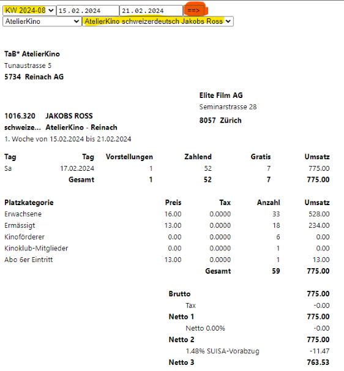

- “Kiosk 02.12.23.txt””  
  Copy paste von html für jede Vorführung und Speichern unter “input/advance tickets/Kiosk xx.xx.xx.txt”.  
  Im Menu auf “DecompteCaisse” https://www.advance-ticket.ch/decomptecaisse?lang=de navigieren.  
  Spalte 1 Das Datum muss gewählt werden, Spalte 2 “reinach”, Splate 3 “Atelierkino Kasse” und Spalte 4 “…” eingestellt werden.

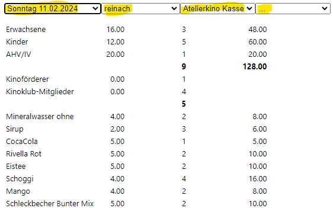

- “Shows.txt”  
  Copy paste von html für die gewünschte Abrechnungsperiode. Bitte speichern unter “input/advance tickets/Shows.txt”  
  Im Menu auf “Shows” https://www.advance-ticket.ch/shows?lang=de navigieren.  
  Spalte 1 startdatum wählen 1.1.20xx, Spalte 2 Enddatum wählen 31.12.20xx

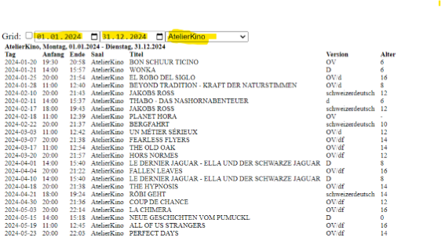

## Script Konfiguration

Inhaltsverzeichnis

Die Datei **“Erstelle Abrechnung.R”** enhält am Anfang die folgenden definition die abgeändert werden können um das Verhalten des Scripts zu beeinflussen.

### Abrechnung für Filmvorführungen

Inhaltsverzeichnis

- Für jede Filmvorführung eine Abrechnung erstellen.  
  `c_run_single` <- TRUE
- Keine Abrechnug für Filmvorführung erstellen.  
  `c_run_single` <- FALSE

### Inhaltsverzeichnisse

Inhaltsverzeichnis

Sollen die erstellten Berichte mit Inhaltsverzeichniss erstellt werden?

- Ja  
  `toc` <- TRUE Ja
- Nein  
  `toc` <- FALSE

### Mehrwertsteuersatz

Inhaltsverzeichnis

c_MWST <- 8.1 #%

### Platzkategorien ohne Umsatz die dennoch abgerechnet werden müssen.

Inhaltsverzeichnis

Für gewisse Verleiher müssen zusätzliche Platzkategorieen abgerechnet werden. Die Defintion findet sich in der Datei “Verleiherabgaben.xlsx” TAB “Kinoförderer gratis”.  
Die Variable `df_P_kat_verechnen` definiert welche Platzkategorien ohne Umsatz zusätzlich verrechnet werden und zu welchem Preis.  
`df_P_kat_verechnen` <- tibble(Kinoförderer = “Kinoförderer”, Verkaufspreis = 13)

### Ausgabeformate

Inhaltsverzeichnis

- `c_render_option` <- “1” only html
- `c_render_option` <- “2” html and docx
- `c_render_option` <- “3” html, docx and pdf (Achtung für pdf install Latex for Windows (Miktex) for Mac (MacTex))

## Excel Dateien

Inhaltsverzeichnis

Im Verzeichniss **…/Kinoklub/input/** kann mit Hilfe von Excelfiles folgendes definiert werden:

### Einkaufspreise

Inhaltsverzeichnis

Die Einkaufspreise die ab einem bestimmten Datum gültig sind. “Einkauf Kiosk xx.xx.xx.xlsx”  
Die Einkaufspreise für die Kioskverkäufe müssen gepflegt werden. Ändern sich die Einkaufspreise so muss ein neues File mit neuerem gültigkeis Datum erstellt werden.

- Achtung!  
  Die alte Dateien dürfen nicht gelöscht werden.

### Spezialpreise Kiosk

Inhaltsverzeichnis

In der Datei **“Spezialpreisekiosk.xlsx”** müssen die Sonderangebote definiert werden.  
Diese Datei wird benötigt um die Spezialpreise

- Spez 1
- Spez 2
- Spez 3
- Spez 4

nach zuschlagen.

### Verleiherabgaben

Inhaltsverzeichnis

Die Verleiherabgaben müssen in der Datei **“…/Kinoklub/input/Verleiherabgaben.xlsx”** definiert werden.

- Im **Tab Verleiherabgaben** muss der “minimal Abzug” sowie “Abzug %” oder nur der “Abzug fix [CHF]” definiert werden. Beide Einträge sind nicht erlaubt.
- Im **Tab Kinoförderer gratis** muss für jeden Verleiher definiert werden, ob gewisse Platzkategorien (z.B.Kinoförderer Tickets) als gratis abgerechnet werden dürfen.  
  Wenn **nein** gewählt wird, dann werden zusätzlich die Platzkategorieen welche in `c_P_kat_verechnen` definiert sind als Umsatz verrechnet.  
  Die Verleiherabrechnung wird ändert sich dadurch was die Abgeben an den Verleiher vergrössert.

### Einnahmen und Ausgaben

Inhaltsverzeichnis

**“…/Kinoklub/input/Einnahmen und Ausgaben.xlsx”**  
Alle Einnahmen und Ausgaben müssen definiert werden.

## Berichte

Inhaltsverzeichnis

Alle Dateien die erzeugt wurden finden sich im **…/Kinoklub/output/** Verzeichniss.

- Für jede Filmvorführung respektive Datum wird ein Abrechnung erstellt.
- Es wird eine Jahresbarechnung und eine detalierte Jahresabrechnung erstellt.
- Es wird eine Statistik mit Porgnosen erstellt.
- Alle verwendeten Datensätze werden in ein Excelfile abgespeichert.

### Abrechnung Filmvorführung

Inhaltsverzeichnis

Es wird eine Filmabrechnung pro Event (Datum) erstellt.

- Übericht
- Filmvorführung
  - Kino Besucherzahlen und Umsatz
    - Filmabgaben
    - Verleiherrechnung  
      In der Datei **“…/Kinoklub/input/Einnahmen und Ausgaben.xlsx”** in den **Ausgaben**  
      wird die Kategorie **Verleiher** berücksichtigt.
    - Prozentualle Abgaben  
      Der Suisaabzug wird vom Umsatz berechnet.

      In der Datei **“…/Kinoklub/input/Verleiherabgaben.xlsx”** sind **Abzug %**, **Minimal Abzug** oder **Abzug fix [CHF]** definiert.
      1. Fall:  
         **Netto3** x **Abzug %** > **Minimal Abzug**  
         Verleiherabzug: **Netto3** x **Abzug %**
      2. Fall:  
         **Netto3** x **Abzug %** < **Minimal Abzug**  
         Verleiherabzug: **Minimal Abzug**
      3. Fall:  
         **Abzug fix [CHF]**  
         Verleiherabzug: **Abzug fix [CHF]**
    - Reklamematerial und Porto  
      Das **Reklamematerial und Porto** werden aus der Differenz der **Verleiherrechnung** und den **Prozentualle Abgaben** berechnet.
    - MWST auf Verleiherrechnung
      1. Fall: Vereiherrechnung vorhanden  
         MWST wird mit der Verleiherrechnung berechnet.
      2. Fall: Vereiherrechnung nicht vorhanden  
         MWST wird aus dem Umsatz berechnet.
  - Gewinn / Verlust aus Tickerverkauf  
    Der Gewinn/Verlust wird aus **Umsatz** - (**Suisa-Abzug**+**Verleiherabzug**+**MWST**+**Reklamematerial und Porto**)
- Event
  - Einnahmen
    - In der Datei **“…/Kinoklub/input/Einnahmen und Ausgaben.xlsx”** in den **Ausgaben**  
      wird die Kategorie **Vermietung** wird pro Filmabrechnung (Datum) berücksichtigt.
  - Ausgaben
    - In der Datei **“…/Kinoklub/input/Einnahmen und Ausgaben.xlsx”** in den **Ausgaben**  
      wird die **Eventausgaben** wird pro Filmabrechnung (Spieldatum) berücksichtigt.
- Kiosk
  - Gewinn pro Artikel  
    In der Datei **“…/Kinoklub/input/Einkauf Kiosk xx.xxx.xx.xlsx”** ist der Gewinn pro Artikel definiert.
  - Umsatz Für den Verkaufsartikel gibte es keine Definition in der Datei **“…/Kinoklub/input/Einkauf Kiosk xx.xxx.xx.xlsx”**
  - Einnahmen  
    Die Einnahmen werden aus Gewinn pro Artikel und dem Umsatz für Spezialpreise berechnet.
  - Ausgaben  
    Achtung!  
    Für Verkaufsartikel ohne Lieferant müssen Eventausgaben definiert werden.
- Kioskumsatz pro Gast
  - Kioskumsatz aller Gäste
  - Kioskumsatz pro zahlender Gast
- Kasse  
  Die Kioskkasse wird auch für Barauszahlung von stornierten Tickets genutzt.
- Gewinn / Verlust  
  Summe aus Einnahmen und Ausgaben

### Jahresabrechnungen

Inhaltsverzeichnis

Die Einnahmen und Ausgaben werden für die Jahresabrechnung verwendet und je nach Kategorie der Rechnung zugewiesen. Die folgenden Kategorien werden in den Jahresrechnungen separat behandelt.

- Filmvorführungen
  - Eintritt
    - Einnahmen Ticketverkauf
    - Abgaben Ticketverkauf
      - Suisaabgaben
      - Verleiherabgaben
      - Nebenkosten
      - MWST auf Verleiherleistungen
- Event
  - Eventeinnahmen  
    Einnahmen für den Event, z.B. Beiträgemitveranstalter, Eventsponsoring, …
  - Eventausgaben  
    Alle Ausgaben die für den Event, z.B. Werbung, Esswaren, Spesen, …
- Kiosk
  - Einnahmen  
    Die Einnahmen werden mit **“Anzahl x Verkaufspeis für Verkaufsartikel”** berechnet.
  - Ausgaben
    - Einkauf Getränke  
      Die Getränke werden von Theater am Bahnhof eingekauft.  
      Falls in der Datei **…/Kinoklub/input/Einkauf Kiosk xx.xx.xx.xlsx** der Lieferant **“Schüwo”** definiert wurde wird der Verkaufsartikel als Getränk ausgegeben.  
      Der Getränkeeinkauf wird mit **“Anzahl x Einkaufspreis”** berechnet.
    - Einkauf Kino  
      Für alle Verkaufsartikel mit Ausnahme der Getränke wird in der Datei **“…/Kinoklub/input/Einnahmen und Ausgaben.xlsx”** mit Kategorie **Kiosk** definiert.
- Vermietung
  - Einnahmen  
    Vermietung Kinosaal, Beiträge von mit Veranstallter, …
  - Ausgaben  
    Mietkosten für Filme und Material, …
- Werbung
  - Einnahmen  
    Die Werbeeinnahme aus Kinowerbung druch Trailers, Dias für Sponsoren, …
  - Ausgaben  
    Inserate, Drucksachen, Homepage, …
- Personalaufwand  
  Löhne
- Sonstiges
  - Einnahmen  
    Sponsoen, Gönner, Kulturbeiträge, …
  - Ausgaben  
    Kinomiete an Theater am Bahnhof AG, Mitgliederbeiträge, Ciné Bulletin, …

### Statistik

Inhaltsverzeichnis

- Gewinn/Verlust
  - Prognose  
    Die Prognose wird mit der Kumuliertensumme pro Datum als lineares Model erstellt.
- Ticketverkauf
  - Prognose  
    Die Prognose wird mit der Kumuliertensumme pro Datum als lineares Model erstellt.
  - Eintritte
    - Anzahl  
      Diagramm
    - Umsatz
      - Prognose  
        Die Prognose wird mit der Kumuliertensumme pro Datum als lineares Model erstellt.
  - Filmabgaben
    - Prognose  
      Die Prognose wird mit der Kumuliertensumme pro Datum als lineares Model erstellt.
- Abos
  - Einnahmen
  - Eingelöst
  - Kredit
- Kiosk-Gewinn pro Vorführung
  - Prognose  
    Die Prognose wird mit der Kumuliertensumme pro Datum als lineares Model erstellt.
- Kiosk
  - Verkaufsartikel
  - Ladenhüter (keine Verkäufe)
  - Kiosk Umsatz pro Gast
    - Prognose  
      Die Prognose wird mit der Kumuliertensumme pro Datum als lineares Model erstellt.
  - Umsatz pro zahlender Gast
    - Prognose  
      Die Prognose wird mit der Kumuliertensumme pro Datum als lineares Model erstellt.